# Aspen Comparison Analysis

Marina

2022-05-15

# Overview

This is a test to show markdown updates. Does this even work?

## Summary

This experiment is to test the simulation’s efficacy at replicating a simple unit cell of a mixture of gases without adsorbents with experimental data. For nature data we’re using the back-end experimental data in Aspen thermodynamic simulation software. To set up this experiment we collected a range of y_co, P, and T and performed a GCMC run for each unique set. The Peng Robinson equation of state is also used here for comparison.

# Setup

## Pull and Combine Aspen Data

```
##    No. Mole fraction CO2 Temperature (K) Pressure (N/sqm) Density (kg/cum) yco
## 1:   1             1.000        335.3339          6998180            152.0 1.0
## 2:   2             0.245        335.4339         13823990            133.8 0.2
## 3:   3             0.245        335.4339         17443740            171.5 0.2
## 4:   4             0.245        335.4339         20822170            204.8 0.2
## 5:   5             0.245        335.4339         27889290            261.5 0.2
## 6:   6             0.245        335.4339         34404840            302.2 0.2
##     t_c p_bar  mfrac_co    rhoco     rhome source
## 1: 62.2  70.0 1.0000000 3.453761  0.000000  Aspen
## 2: 62.3 138.2 0.4068596 1.236942  4.947767  Aspen
## 3: 62.3 174.4 0.4068596 1.585467  6.341869  Aspen
## 4: 62.3 208.2 0.4068596 1.893316  7.573264  Aspen
## 5: 62.3 278.9 0.4068596 2.417491  9.669964  Aspen
## 6: 62.3 344.0 0.4068596 2.793751 11.175002  Aspen
```

## Pull and Combine GCMC Experimental Data

```
##    exp yco   t_c p_bar s_box n_moves n_equil n_prod placeholder   rhocov
## 1:   1 1.0  62.2  70.0    34    1000 1000000 100000           1 2.975360
## 2:  10 0.2  62.3 631.2    34    1000 1000000 100000           1 3.644838
## 3: 100 0.5 162.4 174.8    34    1000 1000000 100000           1 2.740548
## 4: 101 0.5 162.4 208.9    34    1000 1000000 100000           1 3.436985
## 5: 102 0.5 162.4 267.5    34    1000 1000000 100000           1 4.163277
## 6: 103 0.5 162.4 311.6    34    1000 1000000 100000           1 5.044715
##       rhomev        Env        Pv      Ncov      Nmev     rhocov_s     rhomev_s
## 1:  0.000000  -10916.37  64.02711  70.40002   0.00000 0.0002088538 0.0000000000
## 2: 13.959888 -230754.77 597.64118  86.24054 330.30502 0.0002444243 0.0002023592
## 3:  2.637766  -24904.13 176.97921  64.84412  62.41220 0.0001886376 0.0001420379
## 4:  3.071943  -36437.64 214.54596  81.32253  72.68526 0.0001830784 0.0001953473
## 5:  3.895894  -55604.23 264.57388  98.50733  92.18078 0.0002426402 0.0001960703
## 6:  4.508241  -78066.35 309.21872 119.36305 106.66953 0.0002339859 0.0002454563
##        Env_s      Pv_s   Ncov_s   Nmev_s      time iter
## 1:  2745.284  8.176317 8.208791 0.000000  307.6069    1
## 2: 11206.959 85.478972 9.606852 7.953527 1974.5529    1
## 3:  4007.456 21.033900 7.414210 5.582659  641.5114    1
## 4:  5662.995 25.533631 7.195713 7.677930  760.8322    1
## 5:  7071.406 30.178245 9.536729 7.706346  979.1244    1
## 6:  8445.222 47.131911 9.196580 9.647416 1136.9222    1
```

## Combine the 3 Sources (Aspen, GCMC, pr)

```
## Rows: 23
## Columns: 13
## Rowwise:
## $ yco      <dbl> 1.0, 0.2, 0.2, 0.2, 0.8, 0.8, 0.5, 0.8, 0.5, 0.0, 0.8, 0.5, 0~
## $ t_c      <dbl> 62.2, 62.3, 62.3, 62.3, 62.4, 62.4, 62.4, 62.4, 62.4, 62.4, 6~
## $ p_bar    <dbl> 70.0, 138.2, 174.4, 208.2, 70.0, 104.8, 105.8, 136.2, 139.6, ~
## $ rhoco    <dbl> 3.453761, 1.236942, 1.585467, 1.893316, 2.405248, 4.137859, 2~
## $ rhome    <dbl> 0.0000000, 4.9477674, 6.3418693, 7.5732643, 0.6013120, 1.0344~
## $ Pv       <dbl> 64.02711, 136.36019, 172.60682, 192.20714, 68.57730, 100.9677~
## $ Env      <dbl> -10916.37, -25984.60, -41084.41, -55825.49, -10122.19, -28223~
## $ rhocov   <dbl> 2.975360, 1.191627, 1.537110, 1.866746, 2.373421, 4.019934, 2~
## $ rhomev   <dbl> 0.0000000, 4.5609485, 5.7591714, 6.6075270, 0.6424101, 1.0797~
## $ z_pr     <dbl> 0.7063400, 0.8372632, 0.8290854, 0.8329355, 0.7753966, 0.6719~
## $ rho_pr   <dbl> 3.554281, 5.918124, 7.541978, 8.962050, 3.235808, 5.590032, 4~
## $ rhoco_pr <dbl> 3.554281, 1.183625, 1.508396, 1.792410, 2.588646, 4.472026, 2~
## $ rhome_pr <dbl> 0.0000000, 4.7344991, 6.0335821, 7.1696398, 0.6471615, 1.1180~
```

```
## Rows: 407
## Columns: 13
## Rowwise:
## $ yco      <dbl> 1.0, 0.2, 0.2, 0.2, 0.2, 0.2, 0.2, 0.2, 0.2, 0.2, 0.2, 0.8, 0~
## $ t_c      <dbl> 62.2, 62.3, 62.3, 62.3, 62.3, 62.3, 62.3, 62.3, 62.3, 62.3, 6~
## $ p_bar    <dbl> 70.0, 138.2, 174.4, 208.2, 278.9, 344.0, 419.2, 491.9, 550.9,~
## $ rhoco    <dbl> 3.453761, 1.236942, 1.585467, 1.893316, 2.417491, 2.793751, 3~
## $ rhome    <dbl> 0.000000, 4.947767, 6.341869, 7.573264, 9.669964, 11.175002, ~
## $ Pv       <dbl> 64.02711, 136.36019, 172.60682, 192.20714, 278.59571, 325.419~
## $ Env      <dbl> -10916.37, -25984.60, -41084.41, -55825.49, -100599.30, -1273~
## $ rhocov   <dbl> 2.975360, 1.191627, 1.537110, 1.866746, 2.660750, 2.894820, 3~
## $ rhomev   <dbl> 0.0000000, 4.5609485, 5.7591714, 6.6075270, 8.7420591, 10.069~
## $ z_pr     <dbl> 0.7063400, 0.8372632, 0.8290854, 0.8329355, 0.8664261, 0.9155~
## $ rho_pr   <dbl> 3.554281, 5.918124, 7.541978, 8.962050, 11.541307, 13.471042,~
## $ rhoco_pr <dbl> 3.554281, 1.183625, 1.508396, 1.792410, 2.308261, 2.694208, 3~
## $ rhome_pr <dbl> 0.0000000, 4.7344991, 6.0335821, 7.1696398, 9.2330457, 10.776~
```

# Focused Dataset

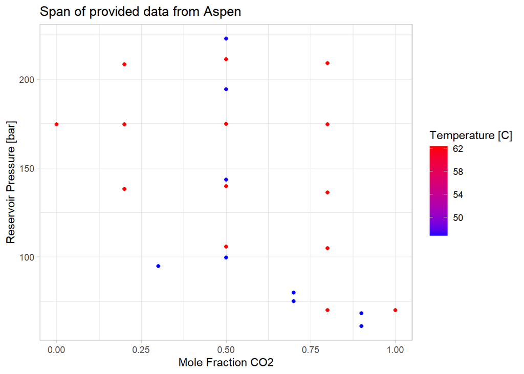

## Mole Fraction

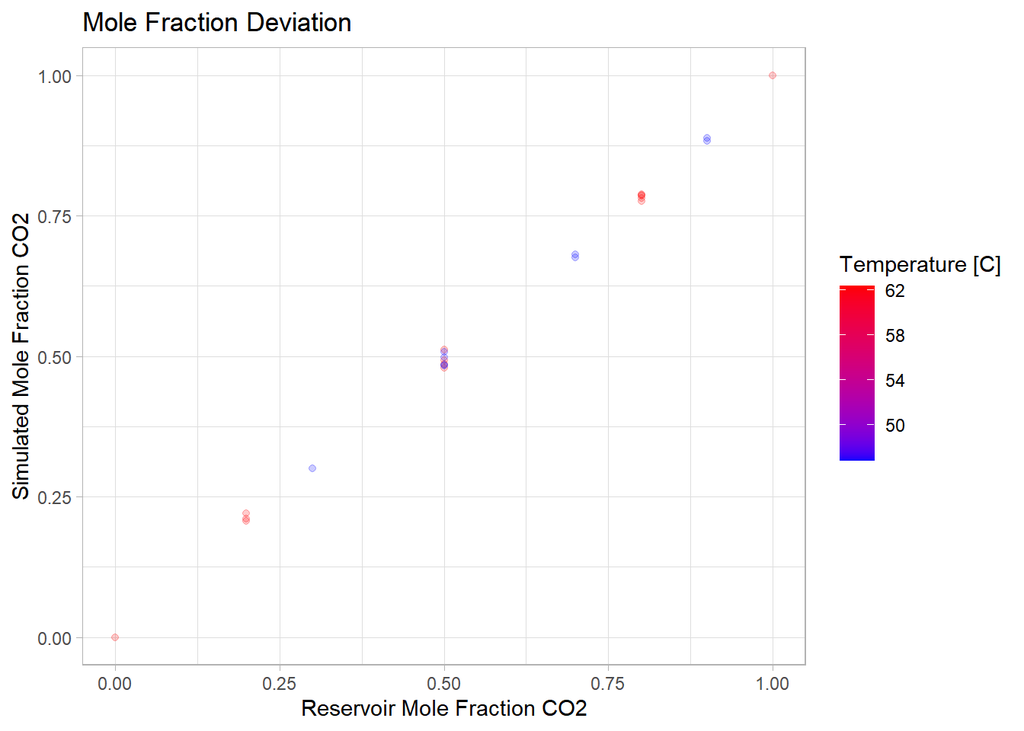

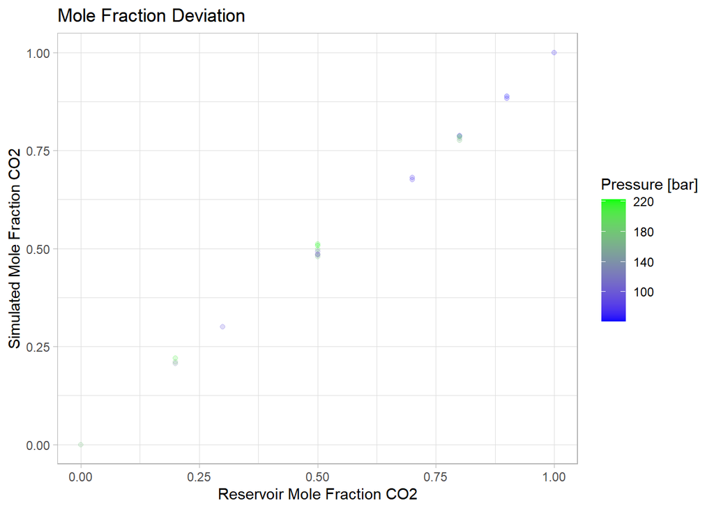

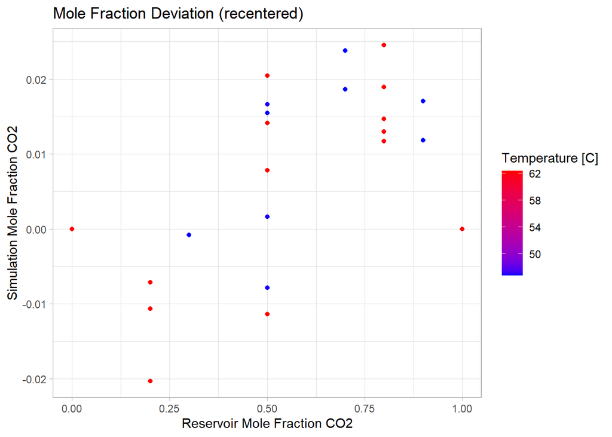

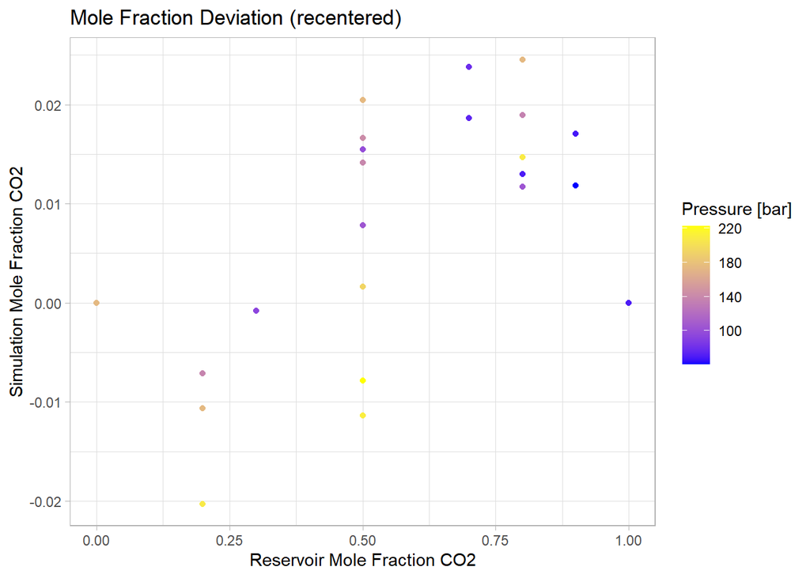

This plot demonstrates the mole fraction difference between reservoir and unit cell. Since there is no adsorbent, there should be no difference between the two and any consistent bias suggests an issue with the simulation’s accuracy. Unfortunately due to the available data we don’t have much to go on here. While there is a suggestion of an overestimation of CO2 in simulation at higher Mole fractions of CO2, there isn’t enough of a range of data to confirm.

## Simulation Pressure

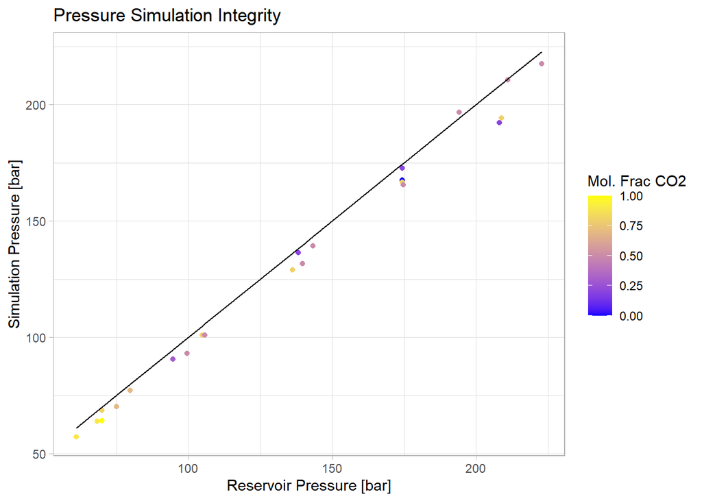

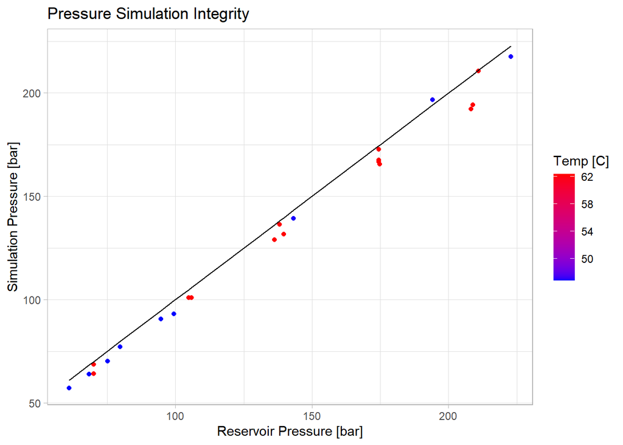

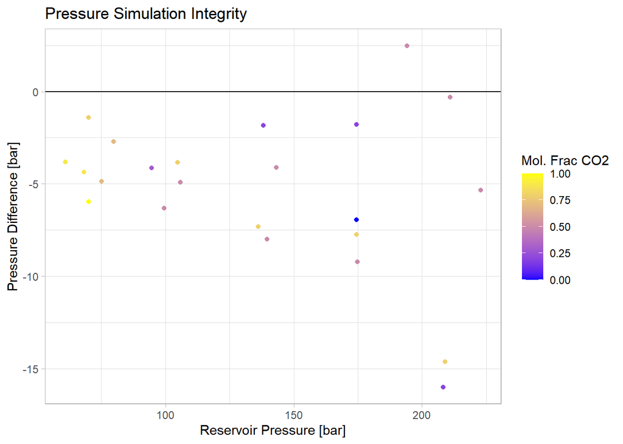

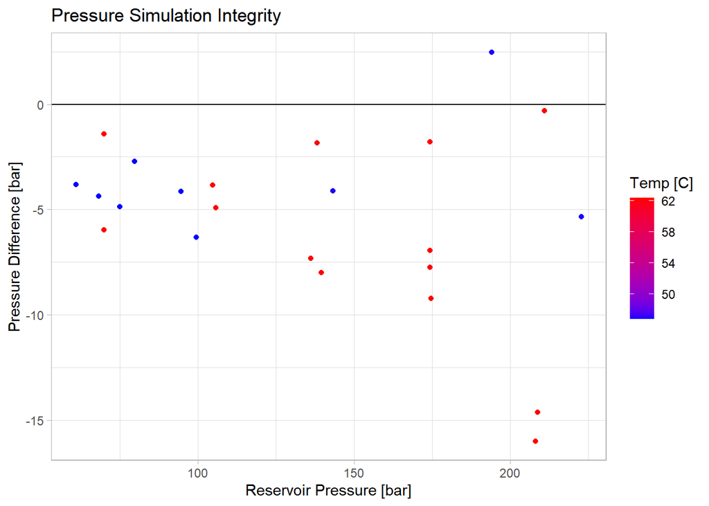

These plots demonstrate the differences in pressure between the reservoir (Aspen) and the unit cell (GCMC). In a perfectly working simulation, these values would be the same as there are no adsorbents to impact the sum of forces on the particles. As shown in the difference plots, the simulation is consistently representing lower pressures in the unit cell across all pressures. The difference in pressure gets worse at higher pressures and at higher temperatures.

Hypothesis: I suspect the difference is due to a mismatch in calculated chemical potential by PR as an input to the system and/or a misrepresentation of CO2’s Lennard-Jones force field. A higher temp/pressure means more particles in the system for the effect of CO2 discrepancy to take place.

## Density Aspen vs GCMC

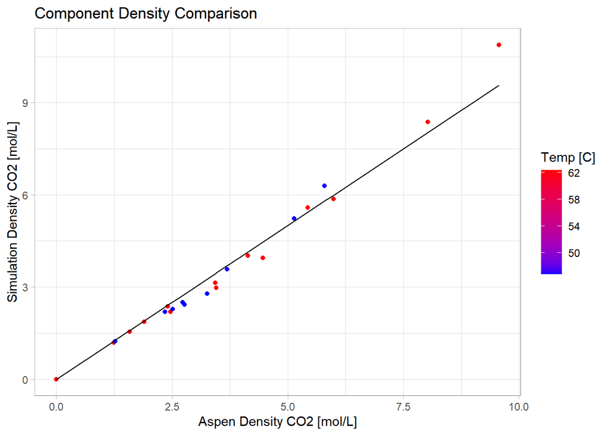

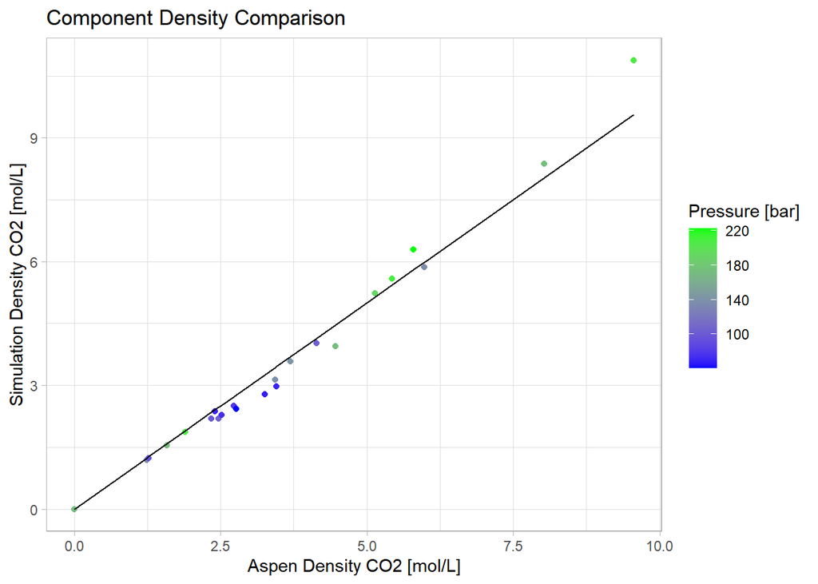

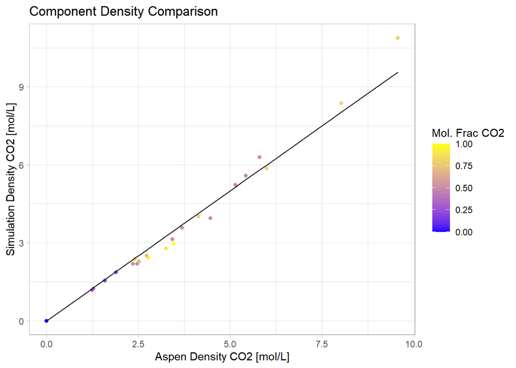

[figure not shown]

[figure not shown]

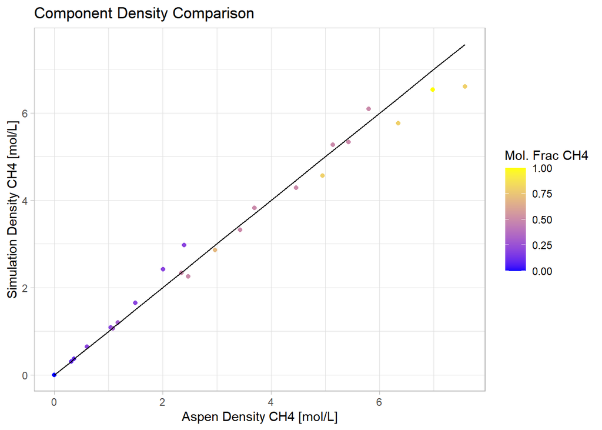

## Density Aspen vs PR

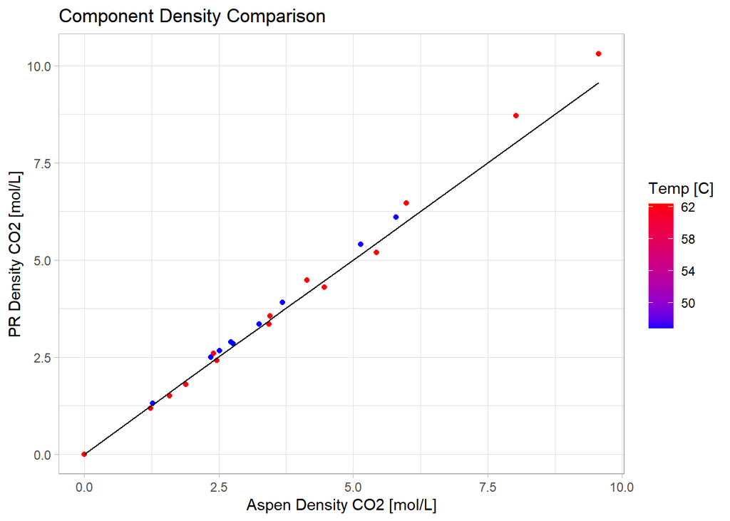

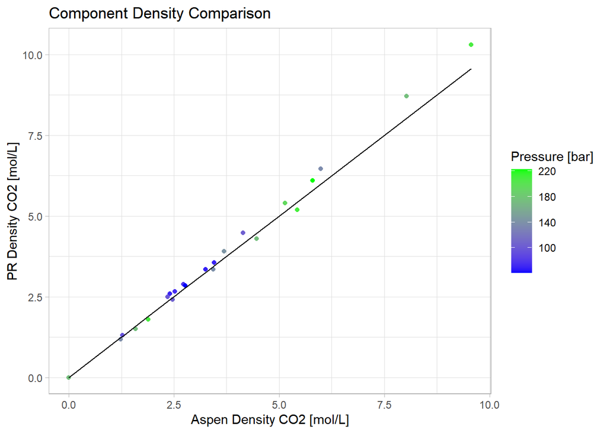

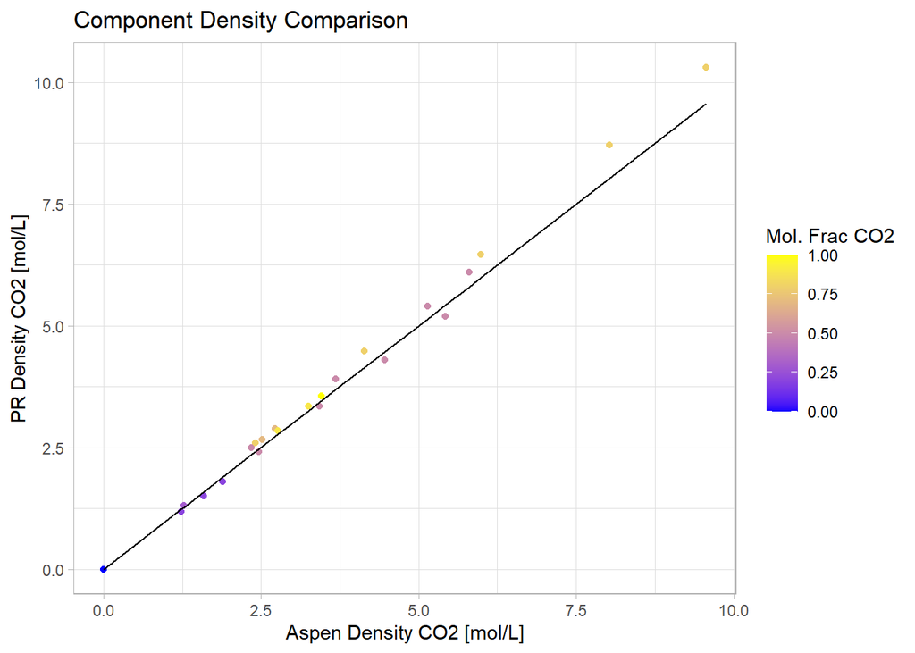

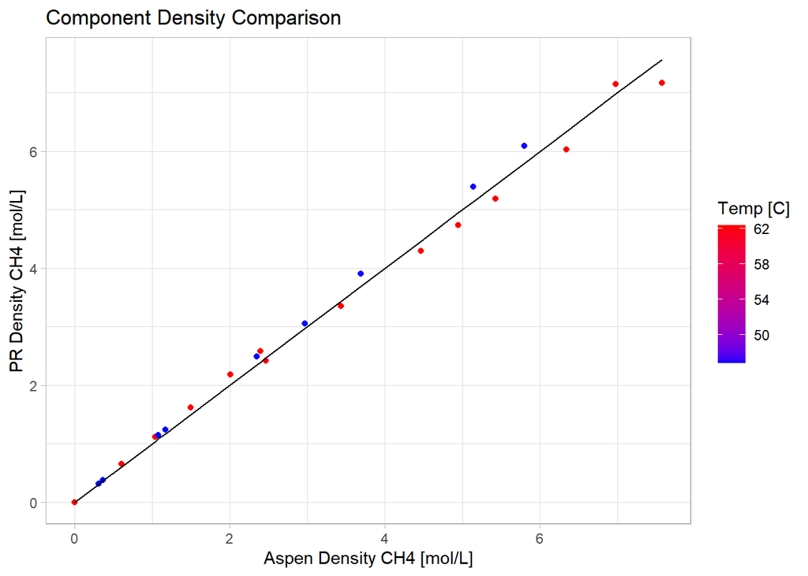

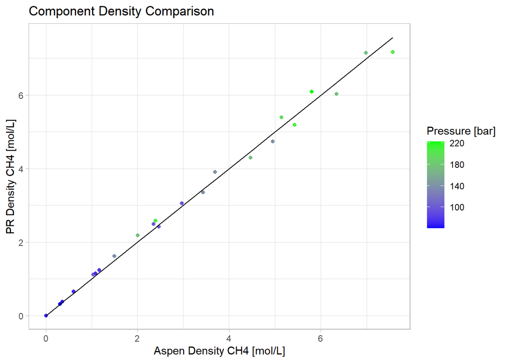

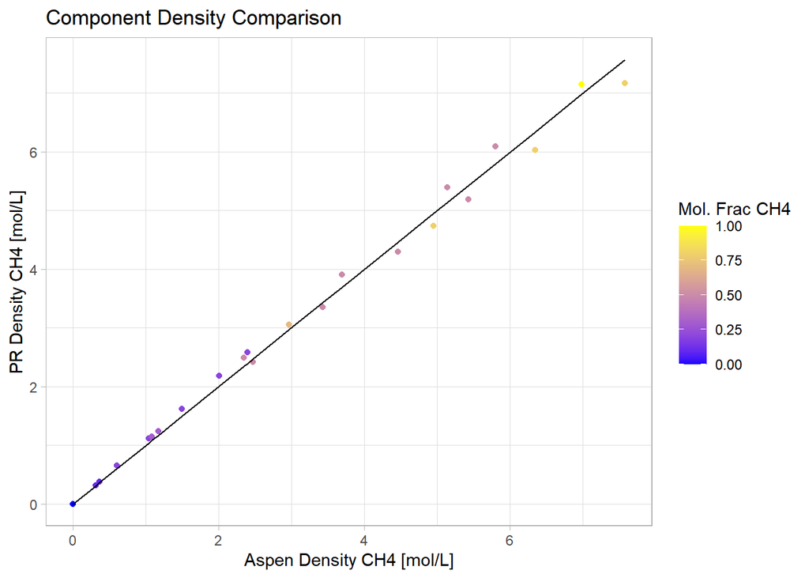

Unexpectedly, the PR results are showing a very same bias away from Aspen experimental data as the gcmc results. This suggests that my chemical potential of the reservoir Equation of State struggles to capture the gas non-ideality in this temperature and pressure range.

## Density GCMC vs PR

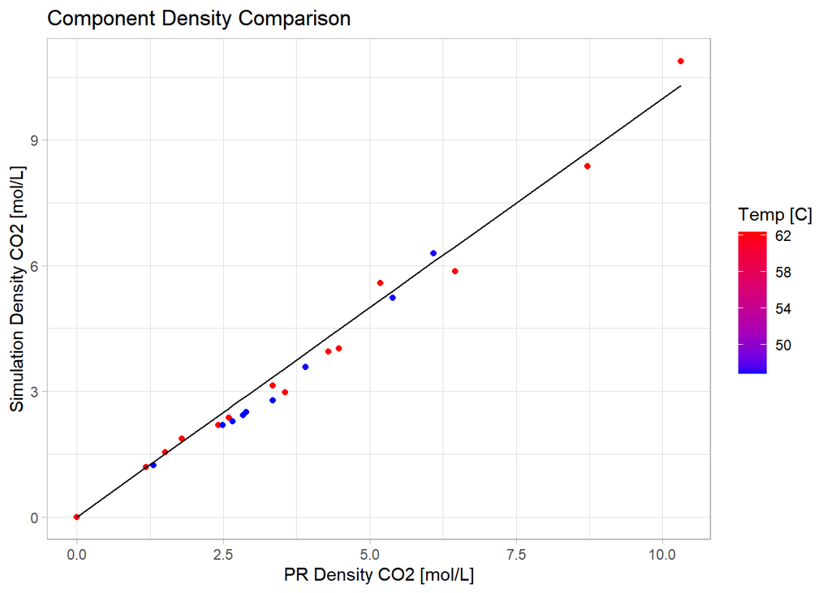

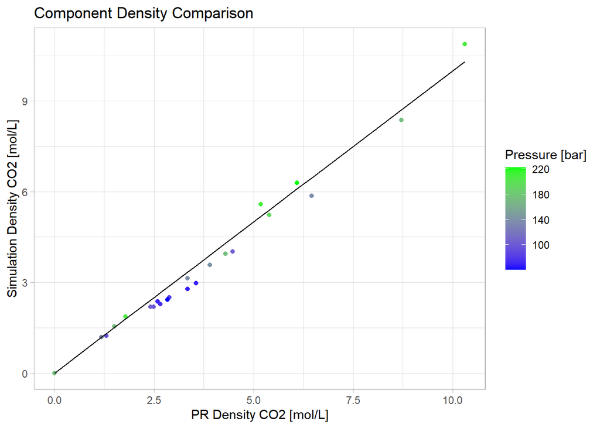

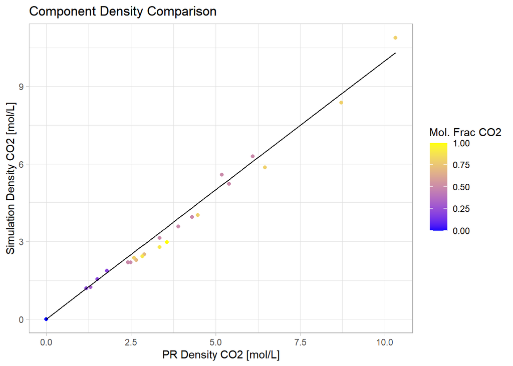

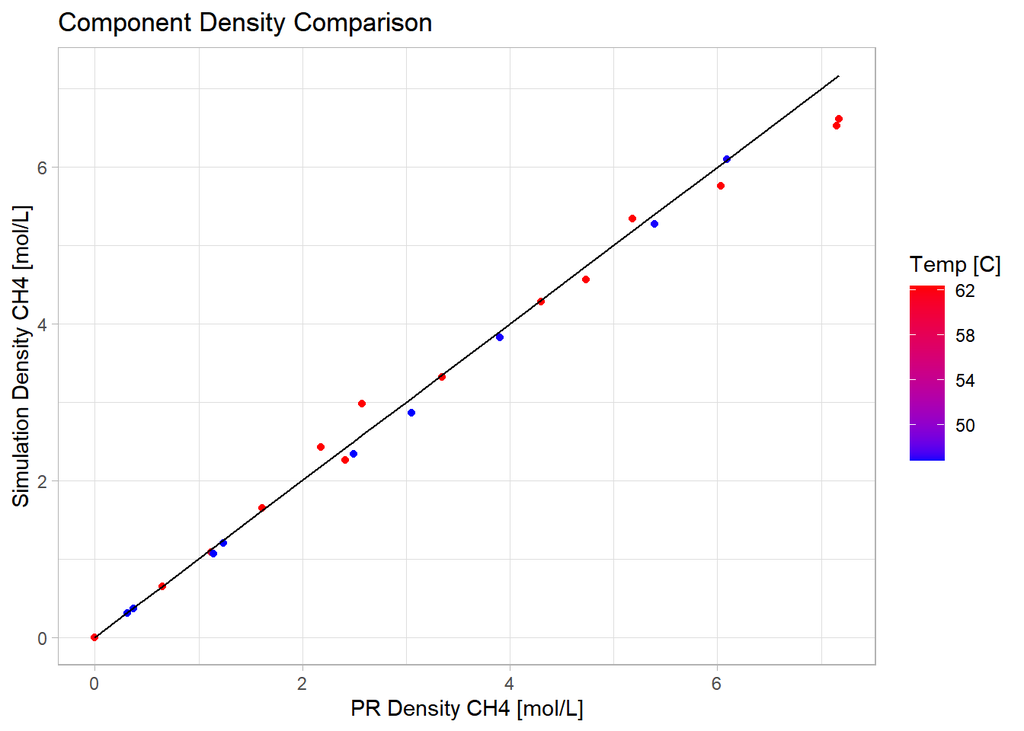

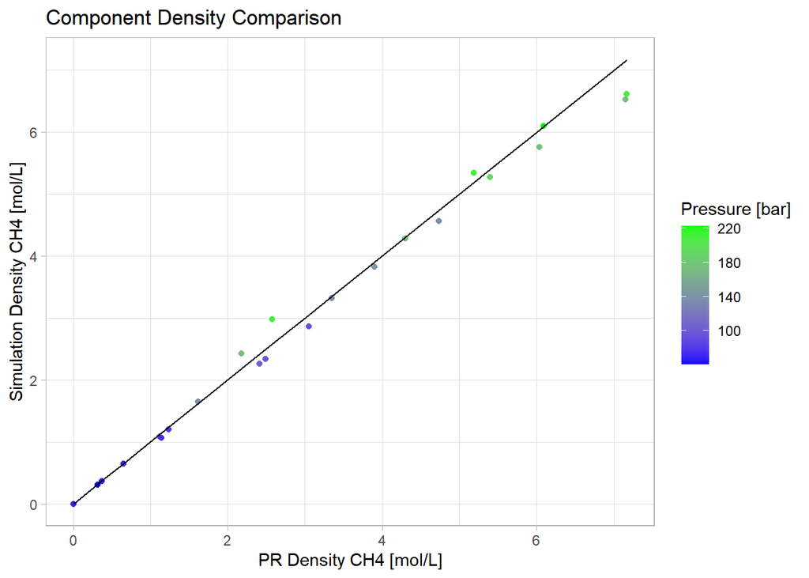

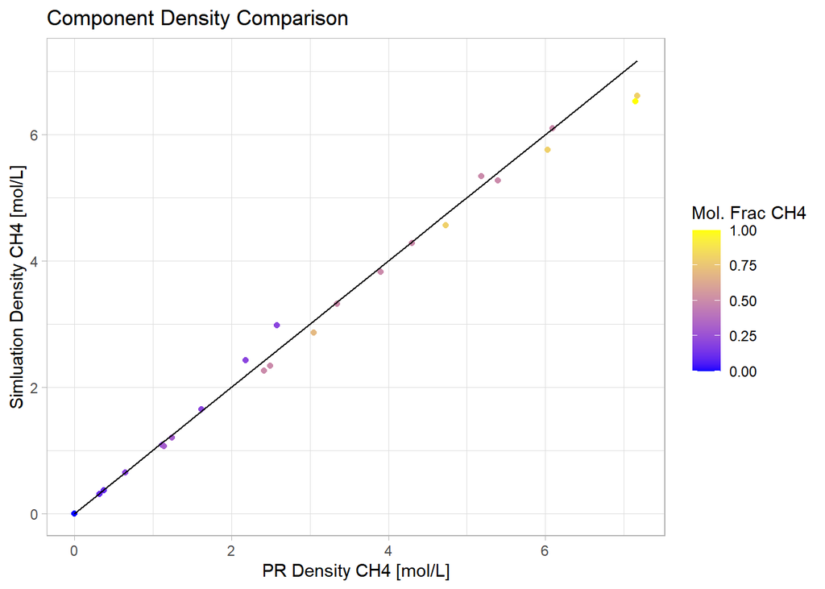

As indicated in the Aspen vs PR comparison, the PR and gcmc are in relative accordance. While PR is used as an input into this model, this is only for determination of chemical potential of the reservoir given y, T, and P. This wouldn’t influence things like specific density beyond chemical potential’s influence.

Next steps:

1. Investigate PR as an EOS when comparing to gas mixtures in this range. This includes debugging the code and modifying parameter values such as Kappa
2. Find more mixture data to compare to, ideally with the full range of y, T, P represented
3. Investigate other Lennard-Jones parameters and pick the best.

# Full Dataset

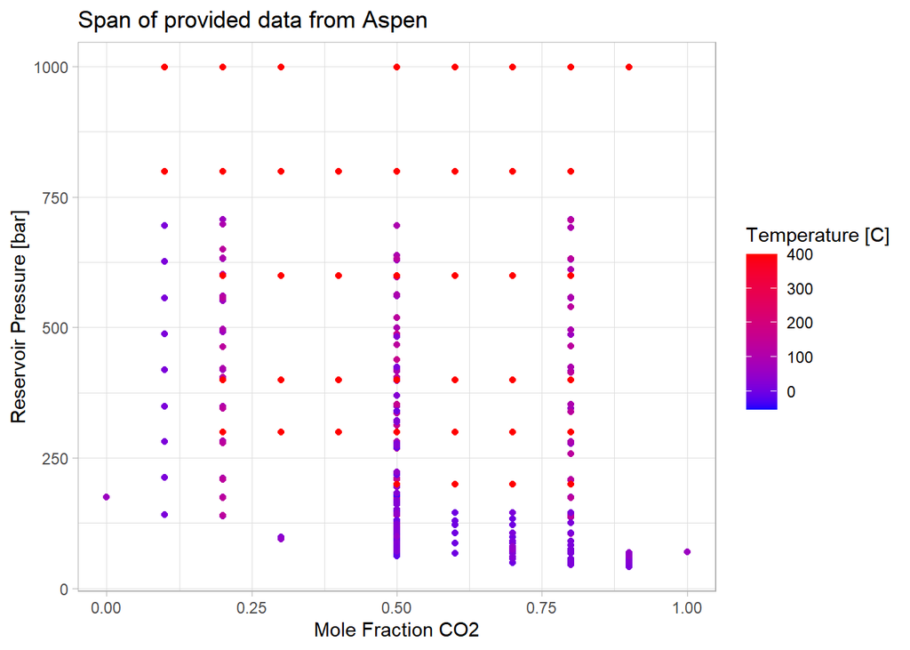

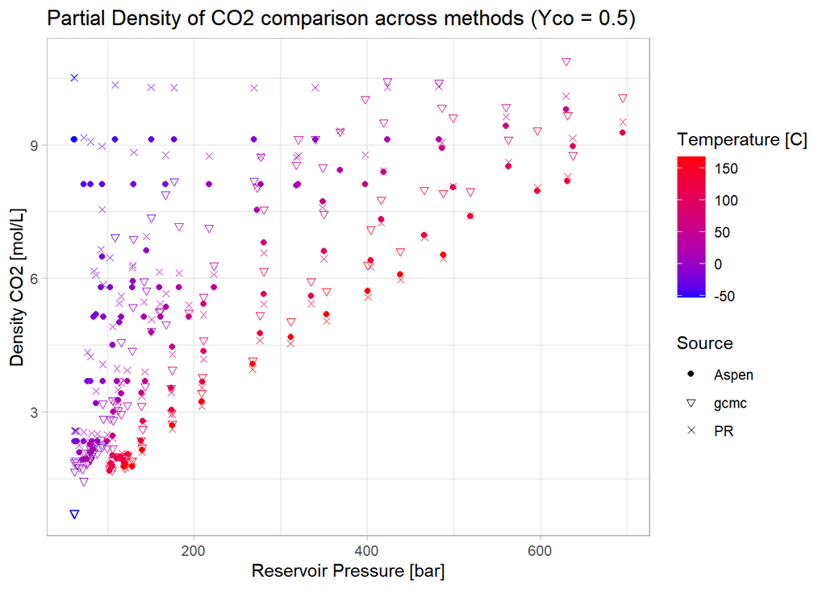

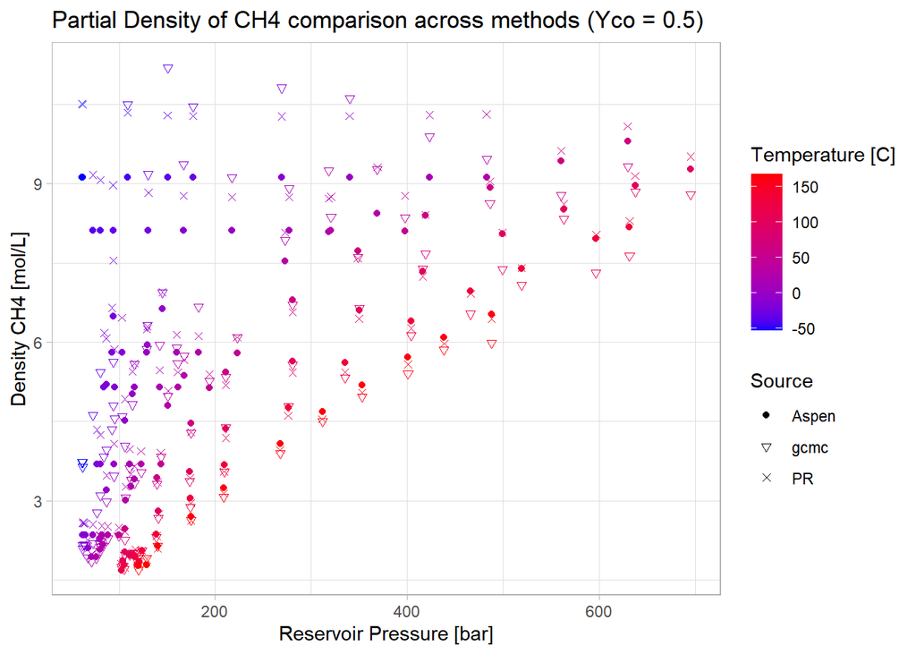

As seen in the smaller dataset examples, Aspen mixture data is biased heavily away from the calculated PR data. It’s likely that the PR equation as used for our reservoir chemical potential calculation is flawed in some way for the range of Temperatures and Pressures we’re studying.

## Mole Fraction

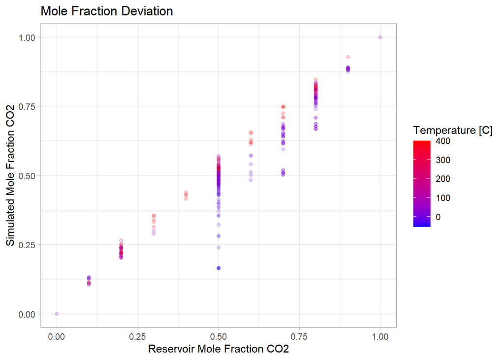

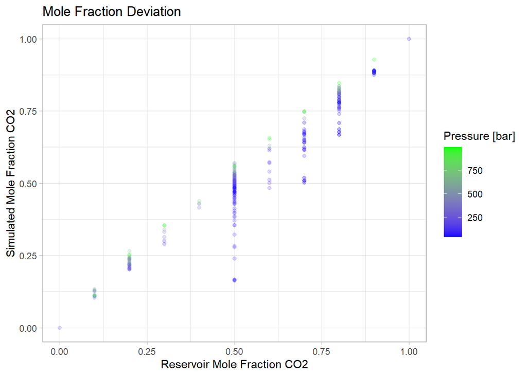

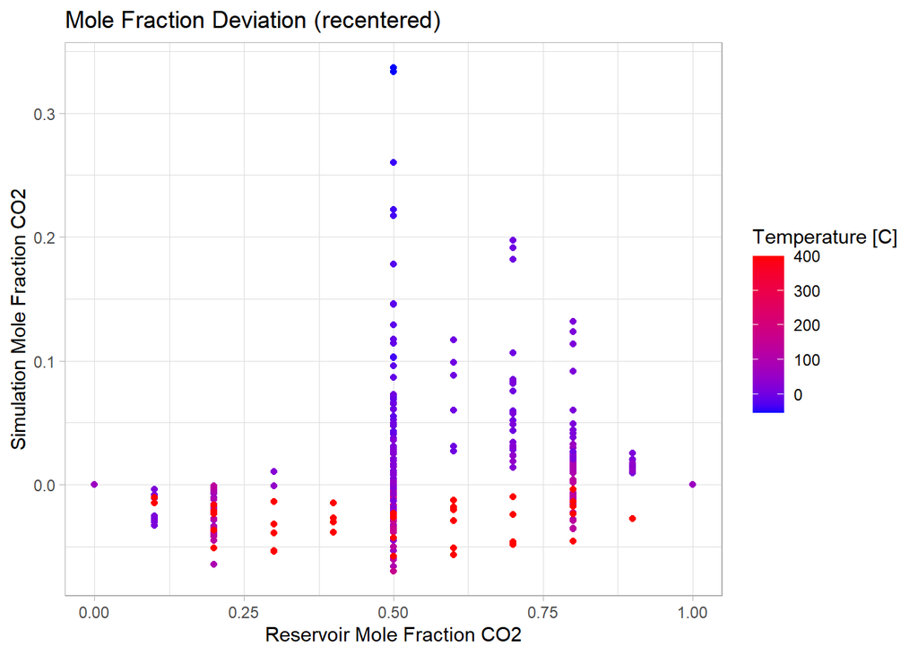

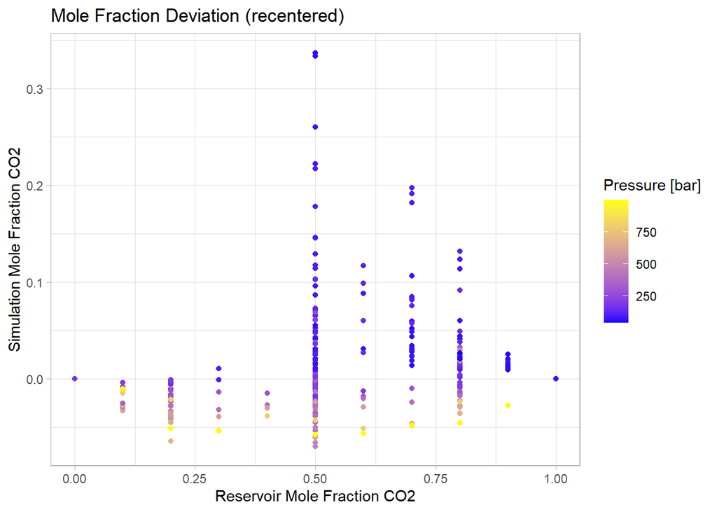

## Simulation Pressure

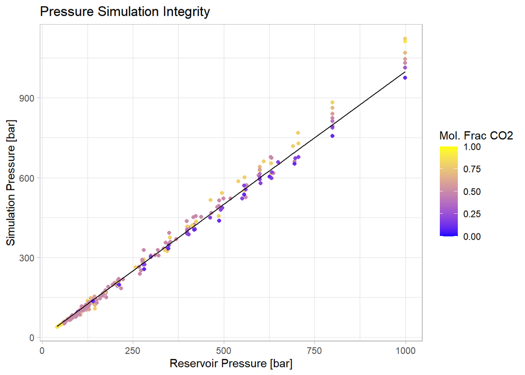

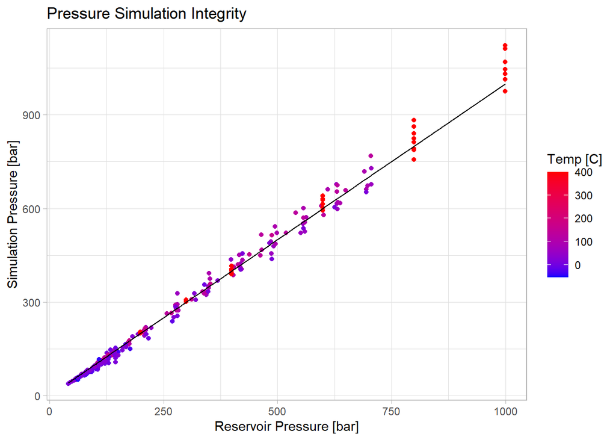

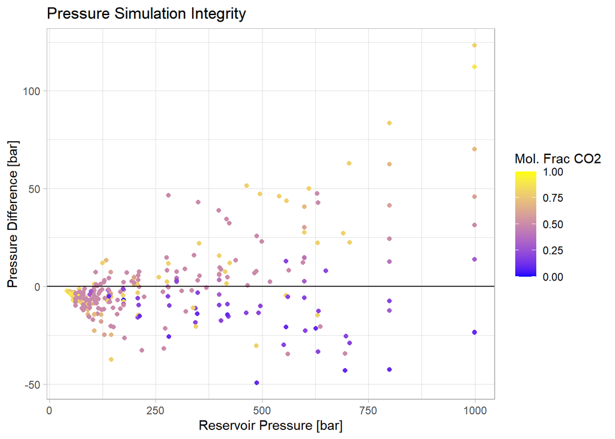

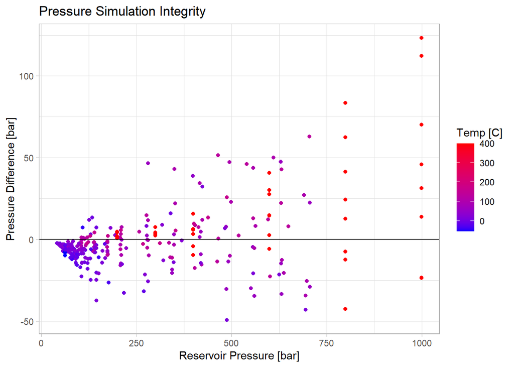

## Density Aspen vs GCMC

### CO2

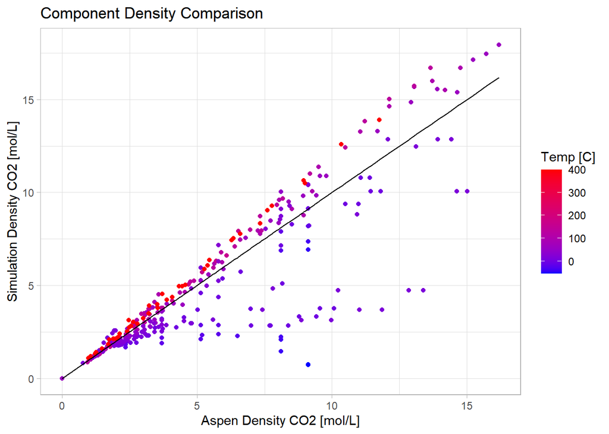

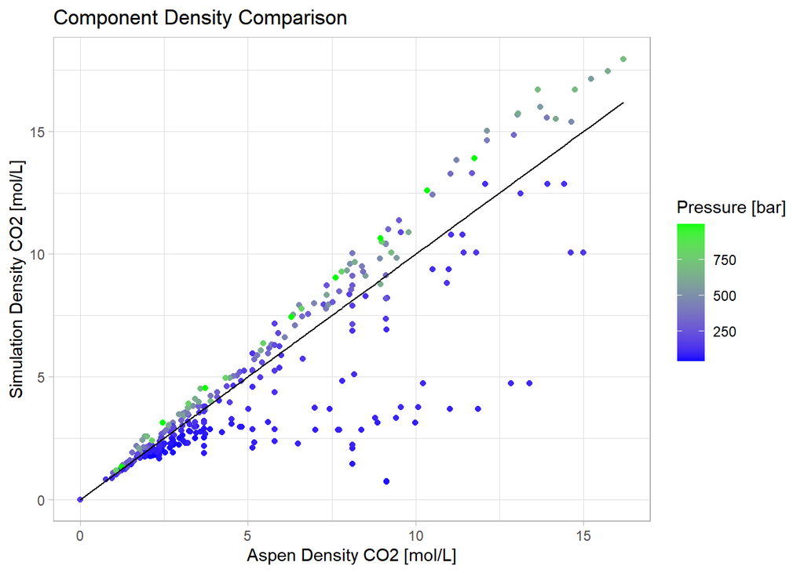

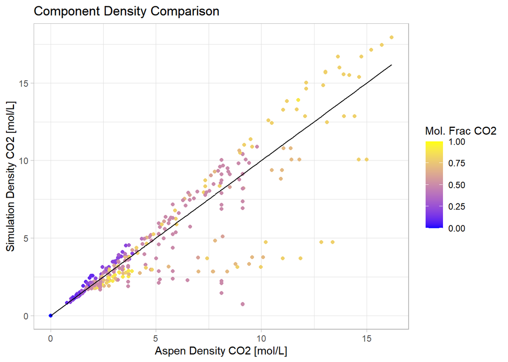

### CH4

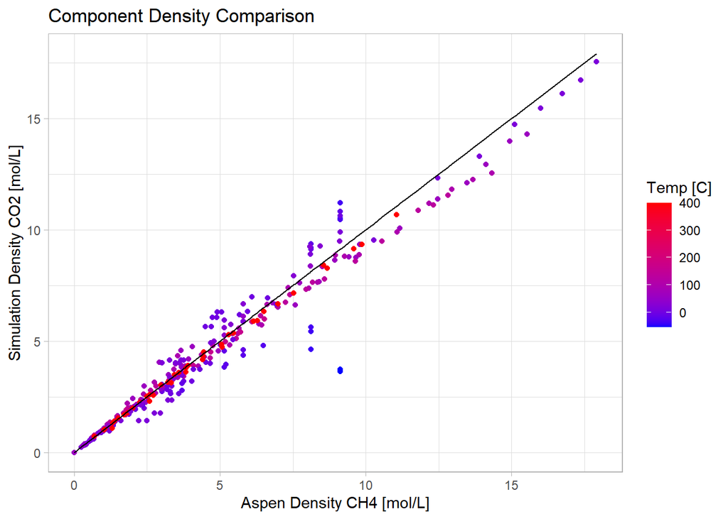

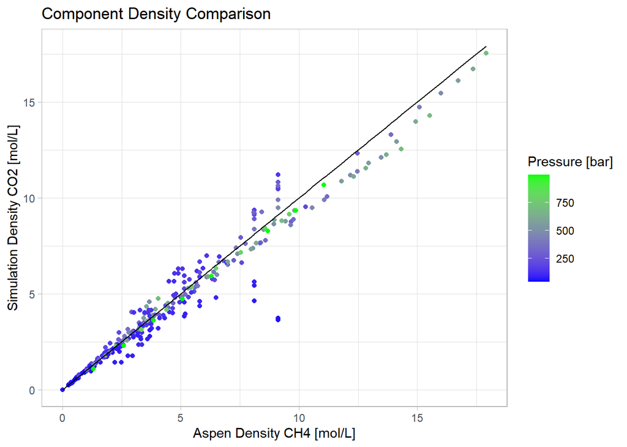

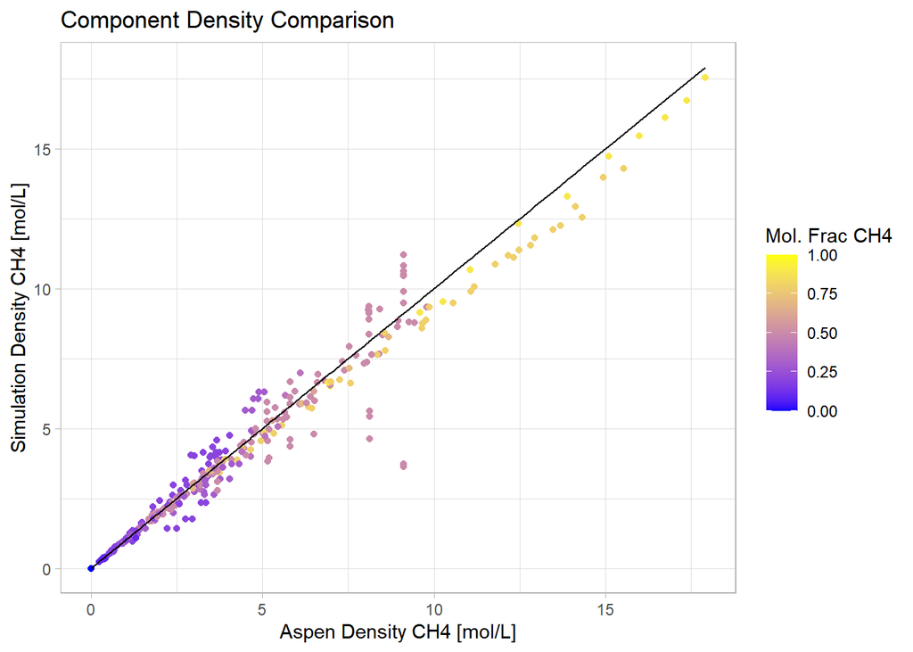